# Statistical inference with the GSS data

## Setup

### Load packages

```r
library(ggplot2)
library(dplyr)
library(statsr)
```

### Load data

```r
load("gss.Rdata")
```

## Part 1: Data

Since 1972, the General Social Survey (GSS) has been monitoring societal change and studying the growing complexity of American society. The GSS aims to gather data on contemporary American society in order to monitor and explain trends and constants in attitudes, behaviors, and attributes; to examine the structure and functioning of society in general as well as the role played by relevant subgroups; to compare the United States to other societies in order to place American society in comparative perspective and develop cross-national models of human society; and to make high-quality data easily accessible to scholars, students, policy makers, and others, with minimal cost and waiting.

Since 1994 the GSS has been administered to two samples in even-numbered years, each with a target sample size of 1500, rather than to a single 1500-person sample each year. Total sample sizes for these biennial GSSs ranged between 2765 (2002) and 2992 (1994). In 2006 a third sample was added and the sample size was 4510. There have been no oversamples during this period.

The GSS has transitioned from a replicating cross-sectional design to a design that uses rotating panels. Under the new three-wave, rotating panel design in each round of the GSS, a new panel is started, the first reinterview from the previous GSS is conducted, and the second and final reinterview from the GSS panel started four years ago is conducted. In 2008 there were two components: a new 2008 cross-section with 2,023 cases and the first re-interviews (panel) with 1,536 respondents from the 2006 GSS. The 2,023 cases in the cross-section have been previously released as a part of the 1972-2008 cumulative data. This new release includes those 1,536 re-interviewed panel cases along with the 2,023 cases. In 2010 the new rolling panel design was fully implemented for the first time.

It is therefore reasonable that the data set represents a random sample of the population,

## Part 2: Research question

Does there appear to be a relationship between gender and opinion on whether the government should help pay for medical care?

Females are stereotypically considered to be the “more caring” gender and hence one may expect that a larger proportion of females would believe the government should assist with medical care support.

Identifying if there is a gender difference could assist in tailoring political campaigns and/or messaging on this topic. The information could also be used by insurance companies in developing or marketing health insurance products.

## Part 3: Exploratory data analysis

The first step is to analyze the data. Presenting as a barplot gives the following:

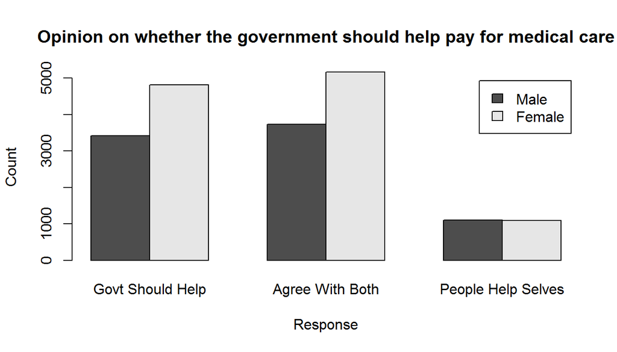

```r
ProjectData<-subset(gss, select = c(caseid, sex, helpsick))
Table_HelpSick = table(ProjectData$sex, ProjectData$helpsick)
barplot(Table_HelpSick, beside=TRUE, main = "Opinion on whether the government should help pay for medical care", xlab = "Response", ylab = "Count", legend.text=c("Male","Female"))
```

By inspection this graph suggests that more females than males feel the government should help pay for medical care. However further analysis is required as the sample may comprise of different numbers of males and females.

```r
Table_HelpSick
```

```
##
##          Govt Should Help Agree With Both People Help Selves
##   Male               3424            3733               1098
##   Female             4817            5170               1085
```

```r
NoMale<-3424+3733+1098
NoMale
```

```
## [1] 8255
```

```r
NoFemale<-4817+5170+1085
NoFemale
```

```
## [1] 11072
```

```r
NoMale+NoFemale
```

```
## [1] 19327
```

The data is comprised of 19,327 individuals, 8,255 of whom are male and 11,072 are female.

We have two categorical variables - gender which has two levels (Male or Female) and opinion on whether the government should help pay for medical care which has three levels (Government should help; People should help themselves and agree with both).

Therefore conduct a Chi-Square Independence Test.

## Part 4: Inference

The hyphotheses are as follows: H0 (nothing going on): Gender and opinion on government medical care are independent. Opinion on whether the government should help pay for medical care does not vary by gender.

H1 (something going on): Gender and opinion on government medical care are dependent. Opinon on whether the government should help pay for medical care varies by gender.

Conditions for the Chi-Square test are: 1) Independence: Sampled observations must be independent. The GSS data was collected through a random sample, without replacement and less than 10% of the population has bee sampled. Each case contributes to only one cell in the table and hence this condition is met. 2) Sample size: Each particular scenario has at least five expected cases.

Both conditions of the Chi-Square test are met.

What proportion of the sample population believes the government should help pay for medical care?

```r
prop.table(Table_HelpSick)
```

```
##
##          Govt Should Help Agree With Both People Help Selves
##   Male         0.17716148      0.19314948         0.05681171
##   Female       0.24923682      0.26750142         0.05613908
```

```r
propHelp<-(0.17716148+0.24923682)
propNoHelp<-(0.05681171+0.05613908)
propAgreeBoth<-(0.19314948+0.26750142)
ftable(propHelp,propAgreeBoth,propNoHelp)
```

```
##                         propNoHelp 0.11295079
## propHelp  propAgreeBoth
## 0.4263983 0.4606509                         1
```

Check proportions are correct. propHelp + propNoHelp + propAgreeBoth should equal 1.

```r
propHelp+propNoHelp+propAgreeBoth
```

```
## [1] 1
```

If in fact gender and opinion on government help pay for medical care are independent then we would expect 42.64% of the sample to believe the government should help, 11.30% to believe that the government should not help and 46.07% to agree with both sides of the argument.

As calculated previously there are 8,255 males in the sample.

```r
ExpectedMHelp<-propHelp*NoMale
ExpectedMNoHelp<-propNoHelp*NoMale
ExpectedMAgreeboth<-propAgreeBoth*NoMale
ftable(ExpectedMHelp,ExpectedMAgreeboth,ExpectedMNoHelp)
```

```
##                                  ExpectedMNoHelp 932.40877145
## ExpectedMHelp ExpectedMAgreeboth
## 3519.9179665  3802.6731795                                  1
```

```r
Table_HelpSick
```

```
##
##          Govt Should Help Agree With Both People Help Selves
##   Male               3424            3733               1098
##   Female             4817            5170               1085
```

Based on our analysis and under the null hypothosis, we would expect approximately 3,520 males to believe the government should help in medical care. This compares with the 3,424 observed.

Test the hypothesis that opinion on government providing medical care and gender are associated at the 5% significance level.

The chi-squared statistic is calcuated as the sum of ((Observed - Expected)^2)/Expected for all scenarios. This calculation can be performed quickly in R.

The degrees of freedom is (Number of rows - 1) x (Number of columns - 1) i.e. (2-1)X(3-1)=2.

```r
summary(Table_HelpSick)
```

```
## Number of cases in table: 19327
## Number of factors: 2
## Test for independence of all factors:
##  Chisq = 58.13, df = 2, p-value = 2.39e-13
```

Check calculation:

```r
pchisq(58.13,2,lower.tail=FALSE)
```

```
## [1] 2.383586e-13
```

The p values calculated are very close to each other so we can use this as a check that R’s calculation is correct.

The p value is very small so we reject the null hypothosis in favor of the alternate hypthosis and conclude that this data provides convincing evidence that there is a relationship between gender and opinon on whether the government should provide medical care.